# ABCDv5.1 Longitudinal depRS

2025-03-13

# Elastic net linear regression using ‘glmnet’

Model predicting year 2 CBCL using environmental factors measured at baseline.

## Data prep

N = 8975 individuals with CBCL data at year 2

N = 7033 individuals with complete CBCL and predictor data.  
N = 4 individuals identifying as gender non-conforming are then excluded before splitting the training and test samples.

Total N = 7029 split into training 80/% (N = 5622) and test 20/% (N = 1407) samples.

# CBCL DSM5-oriented depression subscale

23 predictors were included.

Although glmnet standardises data by default, coefficients are returned on their original scales. To get standardised coefficients for applying to other data, I’m scaling the raw data before inputting to glmnet. Each elastic net model is run with 10-fold cross-validation and lambda/alpha values are selected based on minimising the model mean squared error (MSE).

## Cross-validation

|  | train_mse | test_mse |
| --- | --- | --- |
| alpha_0 | 0.8737118 | 0.8342152 |
| alpha_0.1 | 0.8737347 | 0.8354077 |
| alpha_0.2 | 0.8736306 | 0.8348940 |
| alpha_0.3 | 0.8736042 | 0.8347290 |
| alpha_0.4 | 0.8735927 | 0.8346480 |
| alpha_0.5 | 0.8735863 | 0.8345997 |
| alpha_0.6 | 0.8735822 | 0.8345676 |
| alpha_0.7 | 0.8735795 | 0.8345448 |
| alpha_0.8 | 0.8735773 | 0.8345302 |
| alpha_0.9 | 0.8735758 | 0.8345170 |
| alpha_1 | 0.8735746 | 0.8345064 |

LASSO: $\alpha$ = 1; Ridge: $\alpha$ = 0

Alpha value with the lowest MSE in training sample = alpha_1. Coefficients from this model will be used.

## Plot alphas

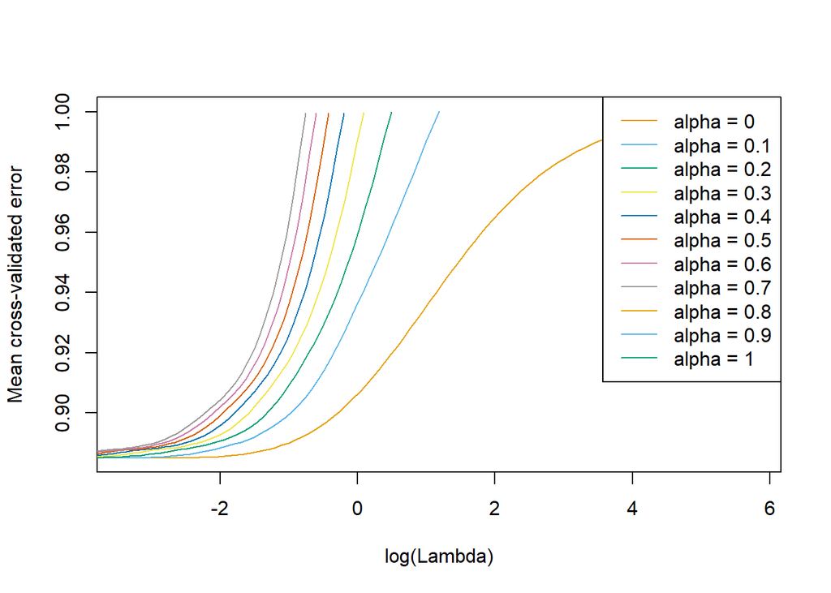

## Plot predictions

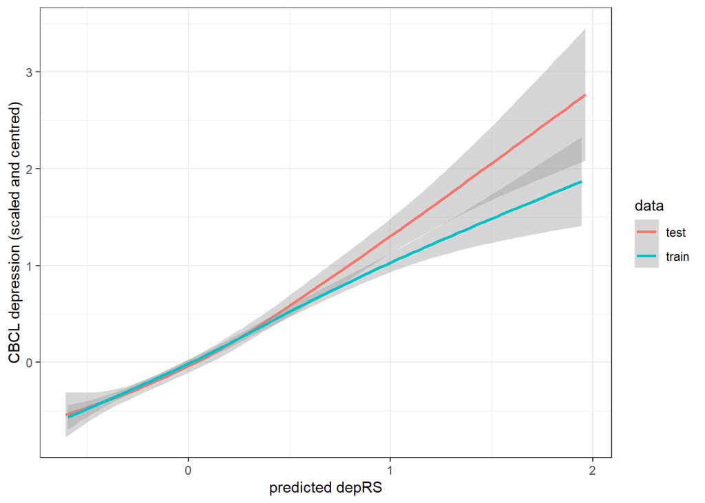

## R-square

|  | test |  |  | train |  |  | whole |  |  |
| --- | --- | --- | --- | --- | --- | --- | --- | --- | --- |
| Predictors | Estimates | CI | p | Estimates | CI | p | Estimates | CI | p |
| (Intercept) | 0.00 | -0.04 – 0.05 | 0.880 | -0.00 | -0.02 – 0.02 | 1.000 | 0.00 | -0.02 – 0.02 | 0.953 |
| lambda min | 1.19 | 1.05 – 1.33 | **<0.001** | 1.02 | 0.95 – 1.09 | **<0.001** | 1.05 | 0.99 – 1.11 | **<0.001** |
| Observations | 1407 |  |  | 5622 |  |  | 7029 |  |  |
| R<sup>2</sup> / R<sup>2</sup> adjusted | 0.169 / 0.169 |  |  | 0.126 / 0.126 |  |  | 0.134 / 0.134 |  |  |

# CBCL internalising subscale

## Cross-validation

|  | train_mse | test_mse |
| --- | --- | --- |
| alpha_0 | 0.8550783 | 0.8181567 |
| alpha_0.1 | 0.8552346 | 0.8190280 |
| alpha_0.2 | 0.8552171 | 0.8190305 |
| alpha_0.3 | 0.8552367 | 0.8190906 |
| alpha_0.4 | 0.8552114 | 0.8190047 |
| alpha_0.5 | 0.8551971 | 0.8189549 |
| alpha_0.6 | 0.8551882 | 0.8189210 |
| alpha_0.7 | 0.8551821 | 0.8188980 |
| alpha_0.8 | 0.8551776 | 0.8188809 |
| alpha_0.9 | 0.8551743 | 0.8188677 |
| alpha_1 | 0.8551716 | 0.8188572 |

Alpha ranges from 0 (ridge regression) to 1 (LASSO)

Alpha value with the lowest MSE in training sample = alpha_0. Coefficients from this model will be used.

## Plot alphas

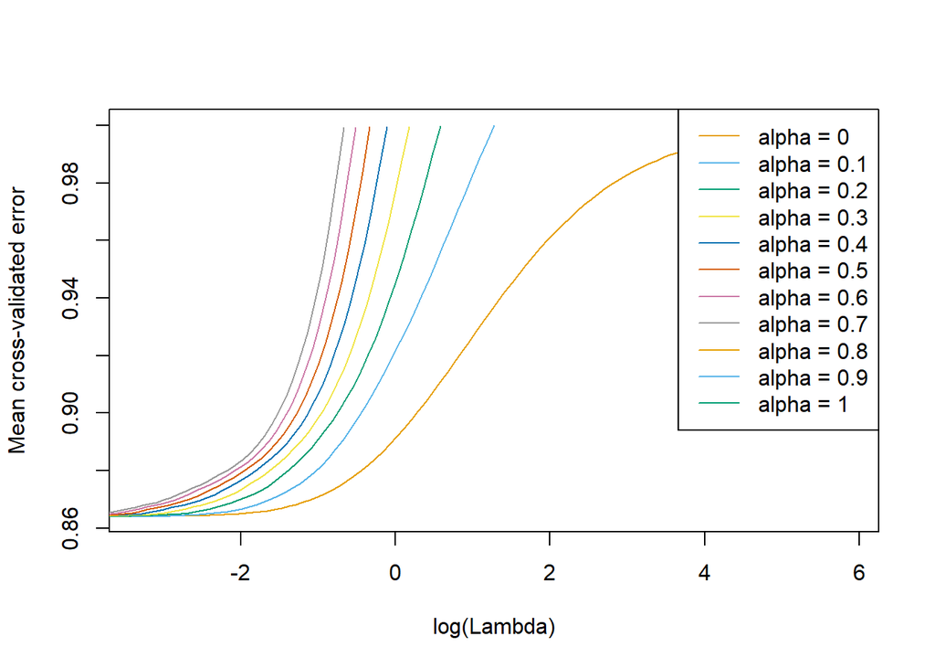

## Plot predictions

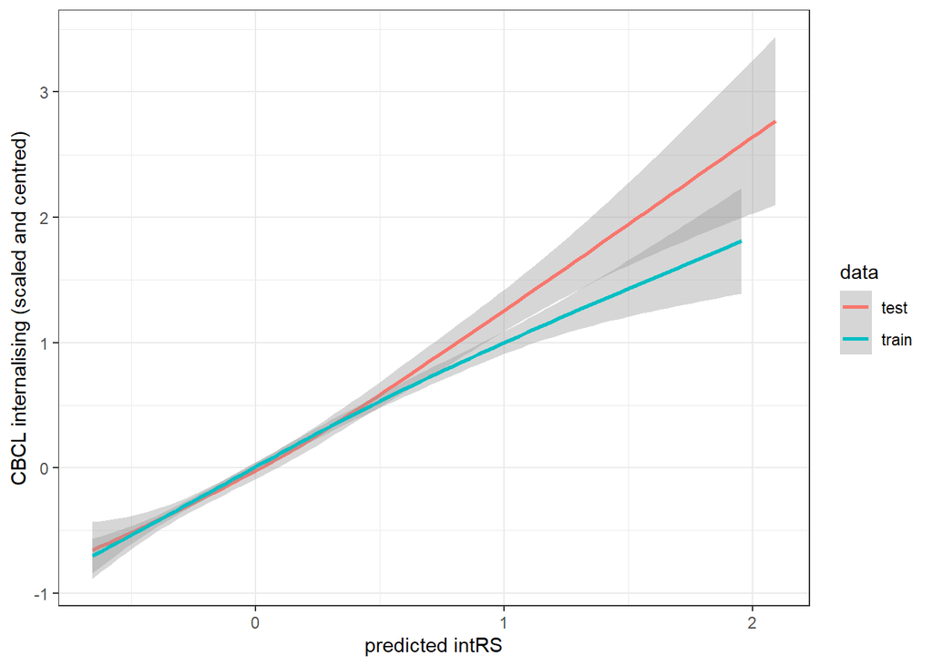

## R-square

|  | test |  |  | train |  |  | whole |  |  |
| --- | --- | --- | --- | --- | --- | --- | --- | --- | --- |
| Predictors | Estimates | CI | p | Estimates | CI | p | Estimates | CI | p |
| (Intercept) | 0.01 | -0.04 – 0.05 | 0.831 | -0.00 | -0.02 – 0.02 | 1.000 | 0.00 | -0.02 – 0.02 | 0.933 |
| lambda min | 1.19 | 1.06 – 1.32 | **<0.001** | 1.04 | 0.98 – 1.11 | **<0.001** | 1.07 | 1.01 – 1.13 | **<0.001** |
| Observations | 1407 |  |  | 5622 |  |  | 7029 |  |  |
| R<sup>2</sup> / R<sup>2</sup> adjusted | 0.186 / 0.185 |  |  | 0.145 / 0.145 |  |  | 0.153 / 0.153 |  |  |

# Coefficients

## Plot

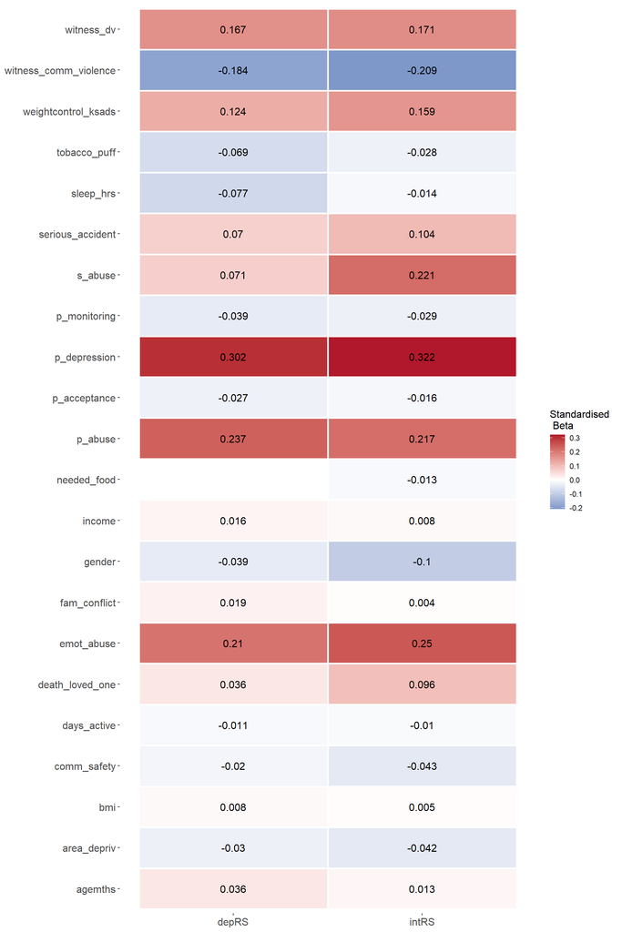

## CBCL depression

| preds | depRS |
| --- | --- |
| p_depression | 0.302 |
| p_abuse | 0.237 |
| emot_abuse | 0.210 |
| witness_dv | 0.167 |
| weightcontrol_ksads | 0.124 |
| s_abuse | 0.071 |
| serious_accident | 0.070 |
| death_loved_one | 0.036 |
| agemths | 0.036 |
| fam_conflict | 0.019 |
| income | 0.016 |
| bmi | 0.008 |
| days_active | -0.011 |
| comm_safety | -0.020 |
| p_acceptance | -0.027 |
| area_depriv | -0.030 |
| p_monitoring | -0.039 |
| gender | -0.039 |
| tobacco_puff | -0.069 |
| sleep_hrs | -0.077 |
| witness_comm_violence | -0.184 |
| (Intercept) | -0.304 |

## CBCL internalising

| preds | intRS |
| --- | --- |
| p_depression | 0.322 |
| emot_abuse | 0.250 |
| s_abuse | 0.221 |
| p_abuse | 0.217 |
| witness_dv | 0.171 |
| weightcontrol_ksads | 0.159 |
| serious_accident | 0.104 |
| death_loved_one | 0.096 |
| agemths | 0.013 |
| income | 0.008 |
| bmi | 0.005 |
| fam_conflict | 0.004 |
| parent_ed | 0.000 |
| days_active | -0.010 |
| needed_food | -0.013 |
| sleep_hrs | -0.014 |
| p_acceptance | -0.016 |
| tobacco_puff | -0.028 |
| p_monitoring | -0.029 |
| area_depriv | -0.042 |
| comm_safety | -0.043 |
| gender | -0.100 |
| witness_comm_violence | -0.209 |
| (Intercept) | -0.824 |

# Coefficients > 0.1

## Plot

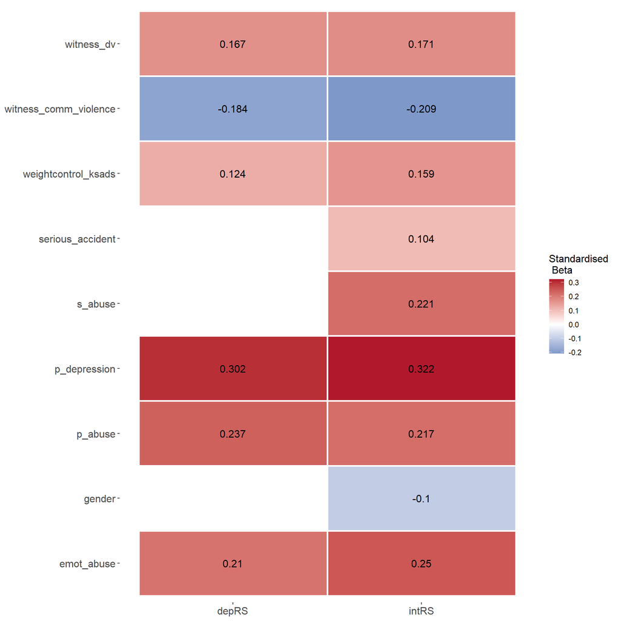

## CBCL depression

[output not shown]

## CBCL internalising

[output not shown]

# Correlation plots

## Whole sample

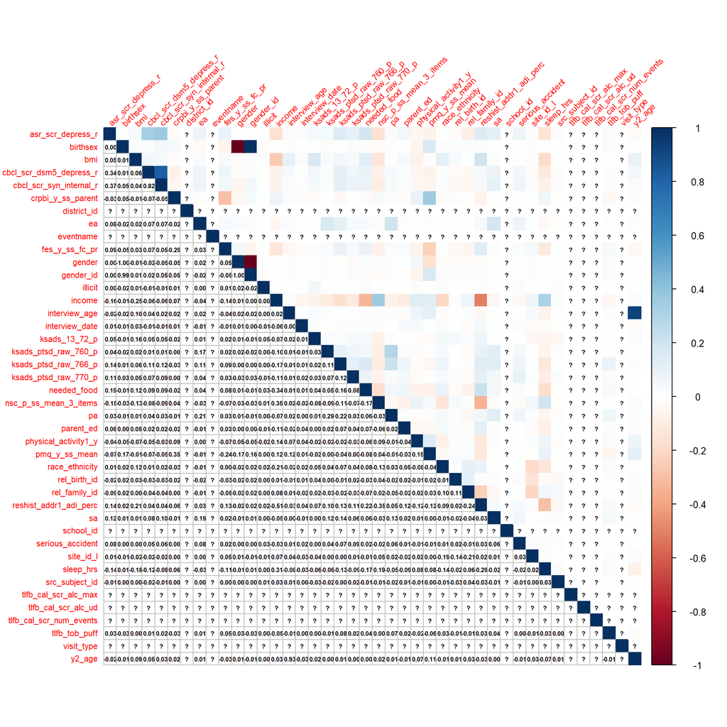

NULL

## Training sample

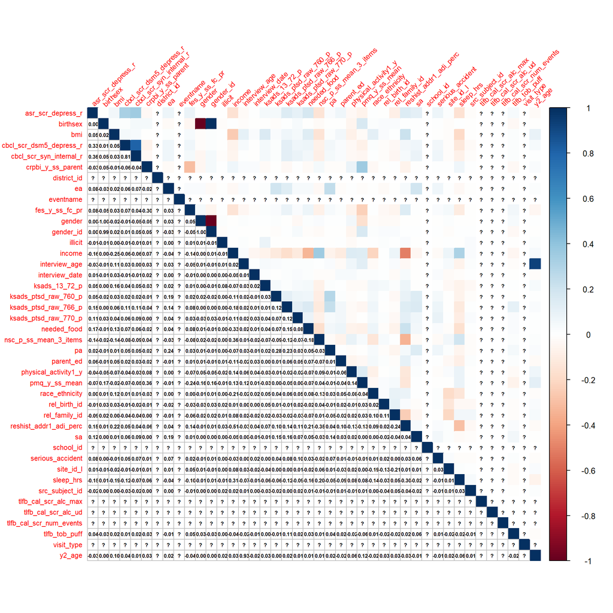

NULL

## Test sample

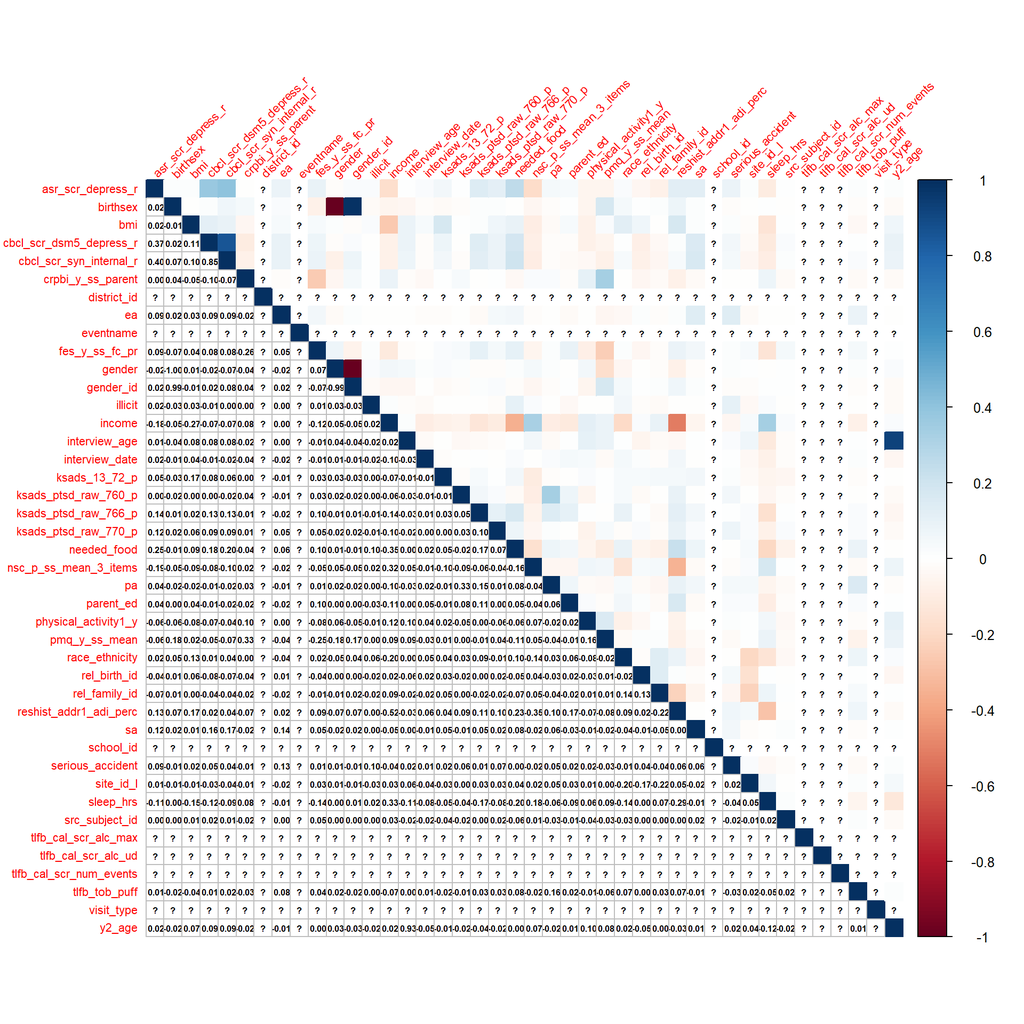

NULL

# Descriptives

## Whole sample

Data Frame Summary

sumdat

**Dimensions**: 7029 x 42  
**Duplicates**: 0

| **Variable** | **Stats / Values** | **Freqs (% of Valid)** | **Graph** | **Missing** |
| --- | --- | --- | --- | --- |
| eventname [factor] | 1. baseline_year_1_arm_1 | 7029 ( 100.0% ) |  | 0 (0.0%) |
| tlfb_cal_scr_alc_ud [integer] | Min : 1 Mean : 1.2 Max : 3 | 1 : 8 ( 88.9% ) 3 : 1 ( 11.1% ) |  | 7020 (99.9%) |
| tlfb_cal_scr_alc_max [numeric] | Mean (sd) : 0.8 (0.6) min ≤ med ≤ max: 0 ≤ 1 ≤ 2 IQR (CV) : 0.7 (0.8) | 6 distinct values |  | 7019 (99.9%) |
| tlfb_cal_scr_num_events [integer] | Mean (sd) : 2.2 (4.8) min ≤ med ≤ max: 0 ≤ 1 ≤ 25 IQR (CV) : 2 (2.2) | 0 : 8 ( 28.6% ) 1 : 12 ( 42.9% ) 2 : 4 ( 14.3% ) 3 : 1 ( 3.6% ) 5 : 1 ( 3.6% ) 8 : 1 ( 3.6% ) 25 : 1 ( 3.6% ) |  | 7001 (99.6%) |
| illicit [factor] | 1. 0 2. 1 | 7027 ( 100.0% ) 2 ( 0.0% ) |  | 0 (0.0%) |
| tlfb_tob_puff [factor] | 1. 0 2. 1 | 6984 ( 99.4% ) 45 ( 0.6% ) |  | 0 (0.0%) |
| ksads_13_72_p [factor] | 1. 0 2. 1 | 6850 ( 97.5% ) 179 ( 2.5% ) |  | 0 (0.0%) |
| ksads_ptsd_raw_760_p [factor] | 1. 0 2. 1 | 6971 ( 99.2% ) 58 ( 0.8% ) |  | 0 (0.0%) |
| ksads_ptsd_raw_770_p [factor] | 1. 0 2. 1 | 5338 ( 75.9% ) 1691 ( 24.1% ) |  | 0 (0.0%) |
| ksads_ptsd_raw_766_p [factor] | 1. 0 2. 1 | 6489 ( 92.3% ) 540 ( 7.7% ) |  | 0 (0.0%) |
| sa [factor] | 1. 0 2. 1 | 6893 ( 98.1% ) 136 ( 1.9% ) |  | 0 (0.0%) |
| pa [factor] | 1. 0 2. 1 | 6966 ( 99.1% ) 63 ( 0.9% ) |  | 0 (0.0%) |
| ea [factor] | 1. 0 2. 1 | 6961 ( 99.0% ) 68 ( 1.0% ) |  | 0 (0.0%) |
| serious_accident [factor] | 1. 0 2. 1 | 6490 ( 92.3% ) 539 ( 7.7% ) |  | 0 (0.0%) |
| sleep_hrs [ordered, factor] | 1. <5hrs 2. 5-7hrs 3. 7-8hrs 4. 8-9hrs 5. 9+hrs | 17 ( 0.2% ) 183 ( 2.6% ) 783 ( 11.1% ) 2510 ( 35.7% ) 3536 ( 50.3% ) |  | 0 (0.0%) |
| bmi [numeric] | Mean (sd) : 18.7 (4.1) min ≤ med ≤ max: 9.8 ≤ 17.6 ≤ 53.9 IQR (CV) : 4.5 (0.2) | 4929 distinct values |  | 0 (0.0%) |
| needed_food [integer] | Min : 0 Mean : 0.1 Max : 1 | 0 : 6523 ( 92.8% ) 1 : 506 ( 7.2% ) |  | 0 (0.0%) |
| income [integer] | Mean (sd) : 7.4 (2.3) min ≤ med ≤ max: 1 ≤ 8 ≤ 10 IQR (CV) : 3 (0.3) | 1 : 202 ( 2.9% ) 2 : 236 ( 3.4% ) 3 : 152 ( 2.2% ) 4 : 293 ( 4.2% ) 5 : 404 ( 5.7% ) 6 : 593 ( 8.4% ) 7 : 981 ( 14.0% ) 8 : 1080 ( 15.4% ) 9 : 2252 ( 32.0% ) 10 : 836 ( 11.9% ) |  | 0 (0.0%) |
| parent_ed [factor] | 1. Bachelor 2. HS/GED 3. less_HS 4. Postgraduate 5. Some_College | 2132 ( 30.3% ) 641 ( 9.1% ) 282 ( 4.0% ) 2011 ( 28.6% ) 1963 ( 27.9% ) |  | 0 (0.0%) |
| birthsex [factor] | 1. M 2. F 3. Intersex | 3734 ( 53.1% ) 3295 ( 46.9% ) 0 ( 0.0% ) |  | 0 (0.0%) |
| gender_id [factor] | 1. M 2. F 3. Mtrans 4. Ftrans 5. GNC 6. Diff | 3729 ( 53.1% ) 3296 ( 46.9% ) 1 ( 0.0% ) 3 ( 0.0% ) 0 ( 0.0% ) 0 ( 0.0% ) |  | 0 (0.0%) |
| gender [factor] | 1. F 2. GNC 3. M | 3299 ( 46.9% ) 0 ( 0.0% ) 3730 ( 53.1% ) |  | 0 (0.0%) |
| race_ethnicity [factor] | 1. White 2. Black 3. Hispanic 4. Asian 5. Other | 3992 ( 56.8% ) 845 ( 12.0% ) 1273 ( 18.1% ) 151 ( 2.1% ) 768 ( 10.9% ) |  | 0 (0.0%) |
| reshist_addr1_adi_perc [integer] | Mean (sd) : 38.4 (26.2) min ≤ med ≤ max: 1 ≤ 32 ≤ 100 IQR (CV) : 36 (0.7) | 100 distinct values |  | 0 (0.0%) |
| nsc_p_ss_mean_3_items [numeric] | Mean (sd) : 3.9 (0.9) min ≤ med ≤ max: 1 ≤ 4 ≤ 5 IQR (CV) : 1.3 (0.2) | 16 distinct values |  | 0 (0.0%) |
| physical_activity1_y [integer] | Mean (sd) : 3.6 (2.3) min ≤ med ≤ max: 0 ≤ 3 ≤ 7 IQR (CV) : 3 (0.6) | 0 : 781 ( 11.1% ) 1 : 801 ( 11.4% ) 2 : 951 ( 13.5% ) 3 : 1010 ( 14.4% ) 4 : 782 ( 11.1% ) 5 : 968 ( 13.8% ) 6 : 528 ( 7.5% ) 7 : 1208 ( 17.2% ) |  | 0 (0.0%) |
| fes_y_ss_fc_pr [numeric] | Mean (sd) : 2 (1.9) min ≤ med ≤ max: 0 ≤ 1 ≤ 9 IQR (CV) : 3 (1) | 11 distinct values |  | 0 (0.0%) |
| pmq_y_ss_mean [numeric] | Mean (sd) : 4.4 (0.5) min ≤ med ≤ max: 1.8 ≤ 4.6 ≤ 5 IQR (CV) : 0.6 (0.1) | 18 distinct values |  | 0 (0.0%) |
| crpbi_y_ss_parent [numeric] | Mean (sd) : 2.8 (0.3) min ≤ med ≤ max: 1 ≤ 2.8 ≤ 3 IQR (CV) : 0.4 (0.1) | 11 distinct values |  | 0 (0.0%) |
| asr_scr_depress_r [integer] | Mean (sd) : 4 (3.6) min ≤ med ≤ max: 0 ≤ 3 ≤ 23 IQR (CV) : 5 (0.9) | 24 distinct values |  | 0 (0.0%) |
| site_id_l [character] | 1. site16 2. site04 3. site13 4. site06 5. site10 6. site17 7. site20 8. site12 9. site21 10. site03 [ 12 others ] | 705 ( 10.0% ) 504 ( 7.2% ) 483 ( 6.9% ) 440 ( 6.3% ) 415 ( 5.9% ) 415 ( 5.9% ) 376 ( 5.3% ) 342 ( 4.9% ) 327 ( 4.7% ) 319 ( 4.5% ) 2703 ( 38.5% ) |  | 0 (0.0%) |
| rel_family_id [integer] | Mean (sd) : 5879.1 (3479.1) min ≤ med ≤ max: 3 ≤ 5825 ≤ 11883 IQR (CV) : 6201 (0.6) | 7029 distinct values |  | 0 (0.0%) |
| rel_birth_id [character] | 1. (Empty string) 2. 10001 3. 100011 4. 100021 5. 100031 6. 100041 7. 100051 8. 100061 9. 1001 10. 100101 [ 7019 others ] | 1 ( 0.0% ) 1 ( 0.0% ) 1 ( 0.0% ) 1 ( 0.0% ) 1 ( 0.0% ) 1 ( 0.0% ) 1 ( 0.0% ) 1 ( 0.0% ) 1 ( 0.0% ) 1 ( 0.0% ) 7019 ( 99.9% ) |  | 0 (0.0%) |
| school_id [integer] | Mean (sd) : 62658.7 (34926.2) min ≤ med ≤ max: 0 ≤ 65147 ≤ 124308 IQR (CV) : 58832 (0.6) | 210 distinct values |  | 4771 (67.9%) |
| district_id [integer] | Mean (sd) : 8484.2 (5319.6) min ≤ med ≤ max: 124 ≤ 7923 ≤ 18543 IQR (CV) : 8634 (0.6) | 183 distinct values |  | 2940 (41.8%) |
| interview_date [character] | 1. 11/18/2017 2. 12/02/2017 3. 07/11/2017 4. 10/07/2017 5. 06/03/2017 6. 12/16/2017 7. 07/06/2017 8. 09/23/2017 9. 12/09/2017 10. 03/24/2018 [ 743 others ] | 31 ( 0.4% ) 31 ( 0.4% ) 30 ( 0.4% ) 28 ( 0.4% ) 27 ( 0.4% ) 27 ( 0.4% ) 26 ( 0.4% ) 24 ( 0.3% ) 24 ( 0.3% ) 23 ( 0.3% ) 6758 ( 96.1% ) |  | 0 (0.0%) |
| interview_age [integer] | Mean (sd) : 118.9 (7.4) min ≤ med ≤ max: 107 ≤ 119 ≤ 132 IQR (CV) : 13 (0.1) | 26 distinct values |  | 0 (0.0%) |
| visit_type [integer] | 1 distinct value | 1 : 7029 ( 100.0% ) |  | 0 (0.0%) |
| cbcl_scr_dsm5_depress_r [integer] | Mean (sd) : 1.5 (2.3) min ≤ med ≤ max: 0 ≤ 1 ≤ 22 IQR (CV) : 2 (1.5) | 20 distinct values |  | 0 (0.0%) |
| cbcl_scr_syn_internal_r [integer] | Mean (sd) : 5.1 (5.6) min ≤ med ≤ max: 0 ≤ 3 ≤ 50 IQR (CV) : 6 (1.1) | 42 distinct values |  | 0 (0.0%) |
| y2_age [numeric] | Mean (sd) : 12 (0.7) min ≤ med ≤ max: 10.6 ≤ 12 ≤ 14 IQR (CV) : 1.1 (0.1) | 41 distinct values |  | 0 (0.0%) |
| age_yrs [numeric] | Mean (sd) : 9.9 (0.6) min ≤ med ≤ max: 8.9 ≤ 9.9 ≤ 11 IQR (CV) : 1.1 (0.1) | 26 distinct values |  | 0 (0.0%) |

Generated by summarytools 1.0.1 ([R](https://www.r-project.org/) version 4.4.1)  
2025-03-13

## Training sample

Data Frame Summary

sumdat

**Dimensions**: 5622 x 42  
**Duplicates**: 0

| **Variable** | **Stats / Values** | **Freqs (% of Valid)** | **Graph** | **Missing** |
| --- | --- | --- | --- | --- |
| eventname [factor] | 1. baseline_year_1_arm_1 | 5622 ( 100.0% ) |  | 0 (0.0%) |
| tlfb_cal_scr_alc_ud [integer] | Min : 1 Mean : 1.3 Max : 3 | 1 : 6 ( 85.7% ) 3 : 1 ( 14.3% ) |  | 5615 (99.9%) |
| tlfb_cal_scr_alc_max [numeric] | Mean (sd) : 0.7 (0.7) min ≤ med ≤ max: 0 ≤ 0.8 ≤ 2 IQR (CV) : 0.8 (0.9) | 6 distinct values |  | 5614 (99.9%) |
| tlfb_cal_scr_num_events [integer] | Mean (sd) : 2.4 (5.3) min ≤ med ≤ max: 0 ≤ 1 ≤ 25 IQR (CV) : 2 (2.2) | 0 : 7 ( 30.4% ) 1 : 9 ( 39.1% ) 2 : 3 ( 13.0% ) 3 : 1 ( 4.3% ) 5 : 1 ( 4.3% ) 8 : 1 ( 4.3% ) 25 : 1 ( 4.3% ) |  | 5599 (99.6%) |
| illicit [factor] | 1. 0 2. 1 | 5621 ( 100.0% ) 1 ( 0.0% ) |  | 0 (0.0%) |
| tlfb_tob_puff [factor] | 1. 0 2. 1 | 5592 ( 99.5% ) 30 ( 0.5% ) |  | 0 (0.0%) |
| ksads_13_72_p [factor] | 1. 0 2. 1 | 5477 ( 97.4% ) 145 ( 2.6% ) |  | 0 (0.0%) |
| ksads_ptsd_raw_760_p [factor] | 1. 0 2. 1 | 5572 ( 99.1% ) 50 ( 0.9% ) |  | 0 (0.0%) |
| ksads_ptsd_raw_770_p [factor] | 1. 0 2. 1 | 4251 ( 75.6% ) 1371 ( 24.4% ) |  | 0 (0.0%) |
| ksads_ptsd_raw_766_p [factor] | 1. 0 2. 1 | 5177 ( 92.1% ) 445 ( 7.9% ) |  | 0 (0.0%) |
| sa [factor] | 1. 0 2. 1 | 5509 ( 98.0% ) 113 ( 2.0% ) |  | 0 (0.0%) |
| pa [factor] | 1. 0 2. 1 | 5569 ( 99.1% ) 53 ( 0.9% ) |  | 0 (0.0%) |
| ea [factor] | 1. 0 2. 1 | 5562 ( 98.9% ) 60 ( 1.1% ) |  | 0 (0.0%) |
| serious_accident [factor] | 1. 0 2. 1 | 5174 ( 92.0% ) 448 ( 8.0% ) |  | 0 (0.0%) |
| sleep_hrs [ordered, factor] | 1. <5hrs 2. 5-7hrs 3. 7-8hrs 4. 8-9hrs 5. 9+hrs | 13 ( 0.2% ) 149 ( 2.7% ) 623 ( 11.1% ) 1991 ( 35.4% ) 2846 ( 50.6% ) |  | 0 (0.0%) |
| bmi [numeric] | Mean (sd) : 18.7 (4.1) min ≤ med ≤ max: 9.8 ≤ 17.6 ≤ 45.6 IQR (CV) : 4.5 (0.2) | 4142 distinct values |  | 0 (0.0%) |
| needed_food [integer] | Min : 0 Mean : 0.1 Max : 1 | 0 : 5209 ( 92.7% ) 1 : 413 ( 7.3% ) |  | 0 (0.0%) |
| income [integer] | Mean (sd) : 7.4 (2.3) min ≤ med ≤ max: 1 ≤ 8 ≤ 10 IQR (CV) : 3 (0.3) | 1 : 168 ( 3.0% ) 2 : 196 ( 3.5% ) 3 : 125 ( 2.2% ) 4 : 237 ( 4.2% ) 5 : 330 ( 5.9% ) 6 : 466 ( 8.3% ) 7 : 795 ( 14.1% ) 8 : 846 ( 15.0% ) 9 : 1816 ( 32.3% ) 10 : 643 ( 11.4% ) |  | 0 (0.0%) |
| parent_ed [factor] | 1. Bachelor 2. HS/GED 3. less_HS 4. Postgraduate 5. Some_College | 1688 ( 30.0% ) 521 ( 9.3% ) 227 ( 4.0% ) 1605 ( 28.5% ) 1581 ( 28.1% ) |  | 0 (0.0%) |
| birthsex [factor] | 1. M 2. F 3. Intersex | 3019 ( 53.7% ) 2603 ( 46.3% ) 0 ( 0.0% ) |  | 0 (0.0%) |
| gender_id [factor] | 1. M 2. F 3. Mtrans 4. Ftrans 5. GNC 6. Diff | 3015 ( 53.6% ) 2604 ( 46.3% ) 1 ( 0.0% ) 2 ( 0.0% ) 0 ( 0.0% ) 0 ( 0.0% ) |  | 0 (0.0%) |
| gender [factor] | 1. F 2. GNC 3. M | 2606 ( 46.4% ) 0 ( 0.0% ) 3016 ( 53.6% ) |  | 0 (0.0%) |
| race_ethnicity [factor] | 1. White 2. Black 3. Hispanic 4. Asian 5. Other | 3188 ( 56.7% ) 702 ( 12.5% ) 1023 ( 18.2% ) 117 ( 2.1% ) 592 ( 10.5% ) |  | 0 (0.0%) |
| reshist_addr1_adi_perc [integer] | Mean (sd) : 38.5 (26.3) min ≤ med ≤ max: 1 ≤ 32 ≤ 100 IQR (CV) : 36 (0.7) | 100 distinct values |  | 0 (0.0%) |
| nsc_p_ss_mean_3_items [numeric] | Mean (sd) : 3.9 (0.9) min ≤ med ≤ max: 1 ≤ 4 ≤ 5 IQR (CV) : 1.3 (0.2) | 16 distinct values |  | 0 (0.0%) |
| physical_activity1_y [integer] | Mean (sd) : 3.6 (2.3) min ≤ med ≤ max: 0 ≤ 3 ≤ 7 IQR (CV) : 3 (0.6) | 0 : 619 ( 11.0% ) 1 : 657 ( 11.7% ) 2 : 752 ( 13.4% ) 3 : 804 ( 14.3% ) 4 : 628 ( 11.2% ) 5 : 757 ( 13.5% ) 6 : 426 ( 7.6% ) 7 : 979 ( 17.4% ) |  | 0 (0.0%) |
| fes_y_ss_fc_pr [numeric] | Mean (sd) : 2 (2) min ≤ med ≤ max: 0 ≤ 2 ≤ 9 IQR (CV) : 3 (1) | 11 distinct values |  | 0 (0.0%) |
| pmq_y_ss_mean [numeric] | Mean (sd) : 4.4 (0.5) min ≤ med ≤ max: 1.8 ≤ 4.6 ≤ 5 IQR (CV) : 0.6 (0.1) | 18 distinct values |  | 0 (0.0%) |
| crpbi_y_ss_parent [numeric] | Mean (sd) : 2.8 (0.3) min ≤ med ≤ max: 1 ≤ 2.8 ≤ 3 IQR (CV) : 0.4 (0.1) | 11 distinct values |  | 0 (0.0%) |
| asr_scr_depress_r [integer] | Mean (sd) : 4 (3.6) min ≤ med ≤ max: 0 ≤ 3 ≤ 22 IQR (CV) : 5 (0.9) | 23 distinct values |  | 0 (0.0%) |
| site_id_l [character] | 1. site16 2. site04 3. site13 4. site10 5. site06 6. site17 7. site20 8. site12 9. site21 10. site09 [ 12 others ] | 562 ( 10.0% ) 404 ( 7.2% ) 394 ( 7.0% ) 341 ( 6.1% ) 340 ( 6.0% ) 334 ( 5.9% ) 308 ( 5.5% ) 278 ( 4.9% ) 254 ( 4.5% ) 252 ( 4.5% ) 2155 ( 38.3% ) |  | 0 (0.0%) |
| rel_family_id [integer] | Mean (sd) : 5864.1 (3483.8) min ≤ med ≤ max: 3 ≤ 5805.5 ≤ 11883 IQR (CV) : 6207.8 (0.6) | 5622 distinct values |  | 0 (0.0%) |
| rel_birth_id [character] | 1. (Empty string) 2. 10001 3. 100011 4. 100021 5. 100041 6. 100051 7. 1001 8. 100101 9. 100121 10. 100151 [ 5612 others ] | 1 ( 0.0% ) 1 ( 0.0% ) 1 ( 0.0% ) 1 ( 0.0% ) 1 ( 0.0% ) 1 ( 0.0% ) 1 ( 0.0% ) 1 ( 0.0% ) 1 ( 0.0% ) 1 ( 0.0% ) 5612 ( 99.8% ) |  | 0 (0.0%) |
| school_id [integer] | Mean (sd) : 62577.2 (35104.5) min ≤ med ≤ max: 0 ≤ 65147 ≤ 124308 IQR (CV) : 58435 (0.6) | 210 distinct values |  | 3783 (67.3%) |
| district_id [integer] | Mean (sd) : 8478.7 (5300.9) min ≤ med ≤ max: 124 ≤ 7923 ≤ 18543 IQR (CV) : 8306.2 (0.6) | 177 distinct values |  | 2324 (41.3%) |
| interview_date [character] | 1. 11/18/2017 2. 12/02/2017 3. 07/11/2017 4. 10/07/2017 5. 06/17/2017 6. 02/24/2018 7. 09/23/2017 8. 11/04/2017 9. 12/16/2017 10. 06/03/2017 [ 736 others ] | 25 ( 0.4% ) 25 ( 0.4% ) 24 ( 0.4% ) 23 ( 0.4% ) 22 ( 0.4% ) 21 ( 0.4% ) 21 ( 0.4% ) 21 ( 0.4% ) 21 ( 0.4% ) 20 ( 0.4% ) 5399 ( 96.0% ) |  | 0 (0.0%) |
| interview_age [integer] | Mean (sd) : 118.9 (7.4) min ≤ med ≤ max: 107 ≤ 119 ≤ 132 IQR (CV) : 13 (0.1) | 26 distinct values |  | 0 (0.0%) |
| visit_type [integer] | 1 distinct value | 1 : 5622 ( 100.0% ) |  | 0 (0.0%) |
| cbcl_scr_dsm5_depress_r [integer] | Mean (sd) : 1.5 (2.3) min ≤ med ≤ max: 0 ≤ 1 ≤ 22 IQR (CV) : 2 (1.5) | 19 distinct values |  | 0 (0.0%) |
| cbcl_scr_syn_internal_r [integer] | Mean (sd) : 5 (5.5) min ≤ med ≤ max: 0 ≤ 3 ≤ 50 IQR (CV) : 6 (1.1) | 40 distinct values |  | 0 (0.0%) |
| y2_age [numeric] | Mean (sd) : 12 (0.7) min ≤ med ≤ max: 10.6 ≤ 12 ≤ 13.8 IQR (CV) : 1 (0.1) | 39 distinct values |  | 0 (0.0%) |
| age_yrs [numeric] | Mean (sd) : 9.9 (0.6) min ≤ med ≤ max: 8.9 ≤ 9.9 ≤ 11 IQR (CV) : 1.1 (0.1) | 26 distinct values |  | 0 (0.0%) |

Generated by summarytools 1.0.1 ([R](https://www.r-project.org/) version 4.4.1)  
2025-03-13

## Test sample

Data Frame Summary

sumdat

**Dimensions**: 1407 x 42  
**Duplicates**: 0

| **Variable** | **Stats / Values** | **Freqs (% of Valid)** | **Graph** | **Missing** |
| --- | --- | --- | --- | --- |
| eventname [factor] | 1. baseline_year_1_arm_1 | 1407 ( 100.0% ) |  | 0 (0.0%) |
| tlfb_cal_scr_alc_ud [integer] | 1 distinct value | 1 : 2 ( 100.0% ) |  | 1405 (99.9%) |
| tlfb_cal_scr_alc_max [numeric] | 1 distinct value | 1 : 2 ( 100.0% ) |  | 1405 (99.9%) |
| tlfb_cal_scr_num_events [integer] | Mean (sd) : 1 (0.7) min ≤ med ≤ max: 0 ≤ 1 ≤ 2 IQR (CV) : 0 (0.7) | 0 : 1 ( 20.0% ) 1 : 3 ( 60.0% ) 2 : 1 ( 20.0% ) |  | 1402 (99.6%) |
| illicit [factor] | 1. 0 2. 1 | 1406 ( 99.9% ) 1 ( 0.1% ) |  | 0 (0.0%) |
| tlfb_tob_puff [factor] | 1. 0 2. 1 | 1392 ( 98.9% ) 15 ( 1.1% ) |  | 0 (0.0%) |
| ksads_13_72_p [factor] | 1. 0 2. 1 | 1373 ( 97.6% ) 34 ( 2.4% ) |  | 0 (0.0%) |
| ksads_ptsd_raw_760_p [factor] | 1. 0 2. 1 | 1399 ( 99.4% ) 8 ( 0.6% ) |  | 0 (0.0%) |
| ksads_ptsd_raw_770_p [factor] | 1. 0 2. 1 | 1087 ( 77.3% ) 320 ( 22.7% ) |  | 0 (0.0%) |
| ksads_ptsd_raw_766_p [factor] | 1. 0 2. 1 | 1312 ( 93.2% ) 95 ( 6.8% ) |  | 0 (0.0%) |
| sa [factor] | 1. 0 2. 1 | 1384 ( 98.4% ) 23 ( 1.6% ) |  | 0 (0.0%) |
| pa [factor] | 1. 0 2. 1 | 1397 ( 99.3% ) 10 ( 0.7% ) |  | 0 (0.0%) |
| ea [factor] | 1. 0 2. 1 | 1399 ( 99.4% ) 8 ( 0.6% ) |  | 0 (0.0%) |
| serious_accident [factor] | 1. 0 2. 1 | 1316 ( 93.5% ) 91 ( 6.5% ) |  | 0 (0.0%) |
| sleep_hrs [ordered, factor] | 1. <5hrs 2. 5-7hrs 3. 7-8hrs 4. 8-9hrs 5. 9+hrs | 4 ( 0.3% ) 34 ( 2.4% ) 160 ( 11.4% ) 519 ( 36.9% ) 690 ( 49.0% ) |  | 0 (0.0%) |
| bmi [numeric] | Mean (sd) : 18.6 (4) min ≤ med ≤ max: 11.1 ≤ 17.5 ≤ 53.9 IQR (CV) : 4.3 (0.2) | 1233 distinct values |  | 0 (0.0%) |
| needed_food [integer] | Min : 0 Mean : 0.1 Max : 1 | 0 : 1314 ( 93.4% ) 1 : 93 ( 6.6% ) |  | 0 (0.0%) |
| income [integer] | Mean (sd) : 7.5 (2.2) min ≤ med ≤ max: 1 ≤ 8 ≤ 10 IQR (CV) : 3 (0.3) | 1 : 34 ( 2.4% ) 2 : 40 ( 2.8% ) 3 : 27 ( 1.9% ) 4 : 56 ( 4.0% ) 5 : 74 ( 5.3% ) 6 : 127 ( 9.0% ) 7 : 186 ( 13.2% ) 8 : 234 ( 16.6% ) 9 : 436 ( 31.0% ) 10 : 193 ( 13.7% ) |  | 0 (0.0%) |
| parent_ed [factor] | 1. Bachelor 2. HS/GED 3. less_HS 4. Postgraduate 5. Some_College | 444 ( 31.6% ) 120 ( 8.5% ) 55 ( 3.9% ) 406 ( 28.9% ) 382 ( 27.1% ) |  | 0 (0.0%) |
| birthsex [factor] | 1. M 2. F 3. Intersex | 715 ( 50.8% ) 692 ( 49.2% ) 0 ( 0.0% ) |  | 0 (0.0%) |
| gender_id [factor] | 1. M 2. F 3. Mtrans 4. Ftrans 5. GNC 6. Diff | 714 ( 50.7% ) 692 ( 49.2% ) 0 ( 0.0% ) 1 ( 0.1% ) 0 ( 0.0% ) 0 ( 0.0% ) |  | 0 (0.0%) |
| gender [factor] | 1. F 2. GNC 3. M | 693 ( 49.3% ) 0 ( 0.0% ) 714 ( 50.7% ) |  | 0 (0.0%) |
| race_ethnicity [factor] | 1. White 2. Black 3. Hispanic 4. Asian 5. Other | 804 ( 57.1% ) 143 ( 10.2% ) 250 ( 17.8% ) 34 ( 2.4% ) 176 ( 12.5% ) |  | 0 (0.0%) |
| reshist_addr1_adi_perc [integer] | Mean (sd) : 38 (25.9) min ≤ med ≤ max: 1 ≤ 32 ≤ 100 IQR (CV) : 36 (0.7) | 100 distinct values |  | 0 (0.0%) |
| nsc_p_ss_mean_3_items [numeric] | Mean (sd) : 4 (0.9) min ≤ med ≤ max: 1 ≤ 4 ≤ 5 IQR (CV) : 1 (0.2) | 13 distinct values |  | 0 (0.0%) |
| physical_activity1_y [integer] | Mean (sd) : 3.6 (2.3) min ≤ med ≤ max: 0 ≤ 3 ≤ 7 IQR (CV) : 3 (0.6) | 0 : 162 ( 11.5% ) 1 : 144 ( 10.2% ) 2 : 199 ( 14.1% ) 3 : 206 ( 14.6% ) 4 : 154 ( 10.9% ) 5 : 211 ( 15.0% ) 6 : 102 ( 7.2% ) 7 : 229 ( 16.3% ) |  | 0 (0.0%) |
| fes_y_ss_fc_pr [numeric] | Mean (sd) : 2 (1.9) min ≤ med ≤ max: 0 ≤ 1 ≤ 9 IQR (CV) : 3 (1) | 0 : 393 ( 27.9% ) 1 : 322 ( 22.9% ) 2 : 241 ( 17.1% ) 3 : 163 ( 11.6% ) 4 : 122 ( 8.7% ) 5 : 69 ( 4.9% ) 6 : 49 ( 3.5% ) 7 : 39 ( 2.8% ) 8 : 7 ( 0.5% ) 9 : 2 ( 0.1% ) |  | 0 (0.0%) |
| pmq_y_ss_mean [numeric] | Mean (sd) : 4.4 (0.5) min ≤ med ≤ max: 2 ≤ 4.6 ≤ 5 IQR (CV) : 0.6 (0.1) | 14 distinct values |  | 0 (0.0%) |
| crpbi_y_ss_parent [numeric] | Mean (sd) : 2.8 (0.3) min ≤ med ≤ max: 1.2 ≤ 2.8 ≤ 3 IQR (CV) : 0.4 (0.1) | 1.20 : 1 ( 0.1% ) 1.40 : 5 ( 0.4% ) 1.60 : 6 ( 0.4% ) 1.80 : 12 ( 0.9% ) 2.00 : 35 ( 2.5% ) 2.20 : 41 ( 2.9% ) 2.40 : 116 ( 8.2% ) 2.60 : 180 ( 12.8% ) 2.80 : 309 ( 22.0% ) 3.00 : 702 ( 49.9% ) |  | 0 (0.0%) |
| asr_scr_depress_r [integer] | Mean (sd) : 4 (3.7) min ≤ med ≤ max: 0 ≤ 3 ≤ 23 IQR (CV) : 5 (0.9) | 24 distinct values |  | 0 (0.0%) |
| site_id_l [character] | 1. site16 2. site04 3. site06 4. site13 5. site17 6. site10 7. site21 8. site03 9. site11 10. site20 [ 12 others ] | 143 ( 10.2% ) 100 ( 7.1% ) 100 ( 7.1% ) 89 ( 6.3% ) 81 ( 5.8% ) 74 ( 5.3% ) 73 ( 5.2% ) 68 ( 4.8% ) 68 ( 4.8% ) 68 ( 4.8% ) 543 ( 38.6% ) |  | 0 (0.0%) |
| rel_family_id [integer] | Mean (sd) : 5938.9 (3461.1) min ≤ med ≤ max: 5 ≤ 5935 ≤ 11880 IQR (CV) : 6139.5 (0.6) | 1407 distinct values |  | 0 (0.0%) |
| rel_birth_id [character] | 1. 100031 2. 100061 3. 10011 4. 100261 5. 10031 6. 100411 7. 10051 8. 100531 9. 100541 10. 100551 [ 1397 others ] | 1 ( 0.1% ) 1 ( 0.1% ) 1 ( 0.1% ) 1 ( 0.1% ) 1 ( 0.1% ) 1 ( 0.1% ) 1 ( 0.1% ) 1 ( 0.1% ) 1 ( 0.1% ) 1 ( 0.1% ) 1397 ( 99.3% ) |  | 0 (0.0%) |
| school_id [integer] | Mean (sd) : 63016.3 (34171.3) min ≤ med ≤ max: 0 ≤ 62341 ≤ 124288 IQR (CV) : 57132 (0.5) | 175 distinct values |  | 988 (70.2%) |
| district_id [integer] | Mean (sd) : 8506.9 (5400.1) min ≤ med ≤ max: 124 ≤ 7717 ≤ 18487 IQR (CV) : 8826 (0.6) | 127 distinct values |  | 616 (43.8%) |
| interview_date [character] | 1. 11/20/2017 2. 06/12/2017 3. 01/06/2018 4. 02/03/2018 5. 03/03/2018 6. 03/24/2018 7. 04/03/2018 8. 06/03/2017 9. 06/14/2017 10. 08/19/2017 [ 585 others ] | 9 ( 0.6% ) 8 ( 0.6% ) 7 ( 0.5% ) 7 ( 0.5% ) 7 ( 0.5% ) 7 ( 0.5% ) 7 ( 0.5% ) 7 ( 0.5% ) 7 ( 0.5% ) 7 ( 0.5% ) 1334 ( 94.8% ) |  | 0 (0.0%) |
| interview_age [integer] | Mean (sd) : 119 (7.4) min ≤ med ≤ max: 107 ≤ 119 ≤ 132 IQR (CV) : 13 (0.1) | 26 distinct values |  | 0 (0.0%) |
| visit_type [integer] | 1 distinct value | 1 : 1407 ( 100.0% ) |  | 0 (0.0%) |
| cbcl_scr_dsm5_depress_r [integer] | Mean (sd) : 1.6 (2.5) min ≤ med ≤ max: 0 ≤ 1 ≤ 17 IQR (CV) : 2 (1.6) | 18 distinct values |  | 0 (0.0%) |
| cbcl_scr_syn_internal_r [integer] | Mean (sd) : 5.2 (6.1) min ≤ med ≤ max: 0 ≤ 3 ≤ 41 IQR (CV) : 6 (1.2) | 37 distinct values |  | 0 (0.0%) |
| y2_age [numeric] | Mean (sd) : 12 (0.7) min ≤ med ≤ max: 10.6 ≤ 12 ≤ 14 IQR (CV) : 1.2 (0.1) | 39 distinct values |  | 0 (0.0%) |
| age_yrs [numeric] | Mean (sd) : 9.9 (0.6) min ≤ med ≤ max: 8.9 ≤ 9.9 ≤ 11 IQR (CV) : 1.1 (0.1) | 26 distinct values |  | 0 (0.0%) |

Generated by summarytools 1.0.1 ([R](https://www.r-project.org/) version 4.4.1)  
2025-03-13